# Logistic Regression

## Building a spam filter

```r
head(email)
```

```
##   spam to_multiple from cc sent_email                time image attach
## 1    0           0    1  0          0 2011-12-31 22:16:41     0      0
## 2    0           0    1  0          0 2011-12-31 23:03:59     0      0
## 3    0           0    1  0          0 2012-01-01 08:00:32     0      0
## 4    0           0    1  0          0 2012-01-01 01:09:49     0      0
## 5    0           0    1  0          0 2012-01-01 02:00:01     0      0
## 6    0           0    1  0          0 2012-01-01 02:04:46     0      0
##   dollar winner inherit viagra password num_char line_breaks format
## 1      0     no       0      0        0    11.37         202      1
## 2      0     no       0      0        0    10.50         202      1
## 3      4     no       1      0        0     7.77         192      1
## 4      0     no       0      0        0    13.26         255      1
## 5      0     no       0      0        2     1.23          29      0
## 6      0     no       0      0        2     1.09          25      0
##   re_subj exclaim_subj urgent_subj exclaim_mess number
## 1       0            0           0            0    big
## 2       0            0           0            1  small
## 3       0            0           0            6  small
## 4       0            0           0           48  small
## 5       0            0           0            1   none
## 6       0            0           0            1   none
```

```r
# where did this data come from / how was it collected?
```

## How was the data collected?

[figure not shown]

1. Choose a single email account
2. Save each email that comes in during a given time frame
3. Create dummy variables for each text component of interest
4. Visually classify each as spam or not

## Simple Filter A

Predicting spam or not using the presence of "winner"

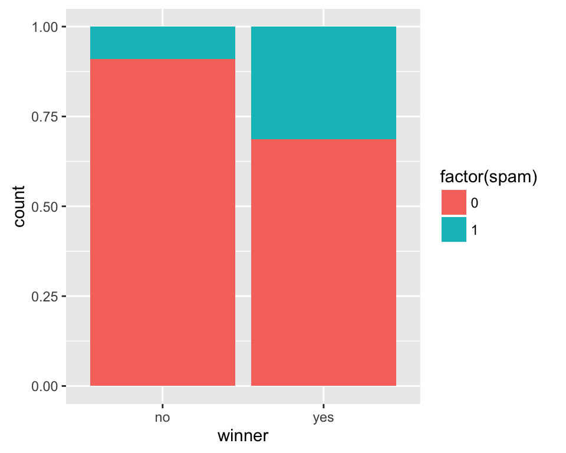

If "winner" then "spam"?

## Simple Filter B

Predicting spam or not using number of characters (in K)

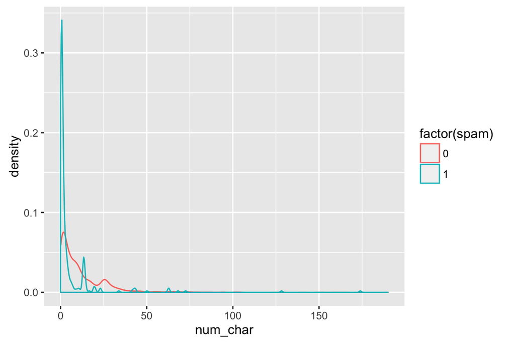

## Simple Filter B

Predicting spam or not using log number of characters (in K)

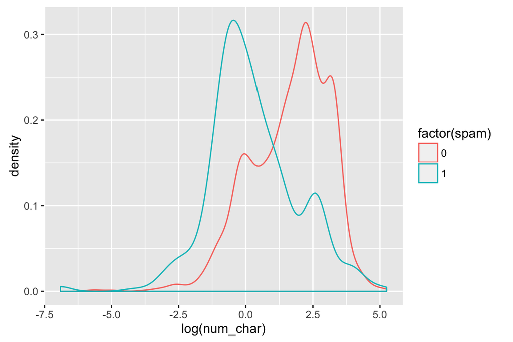

If `log(num_char)` < 1, then "spam"?

## Challenges

Each simple filter can be thought of as a regression model.

### Filter A

\(spam \sim winner; \quad G_1 \sim G_2\)

### Filter B

\(spam \sim log(num\_char); \quad G_1 \sim K_1\)

Each one by itself has poor predictive power, so how can we combine them into a single stronger model?

[figure not shown]

## Logistic Regression for B

\[spam \sim log(num\_char)\]

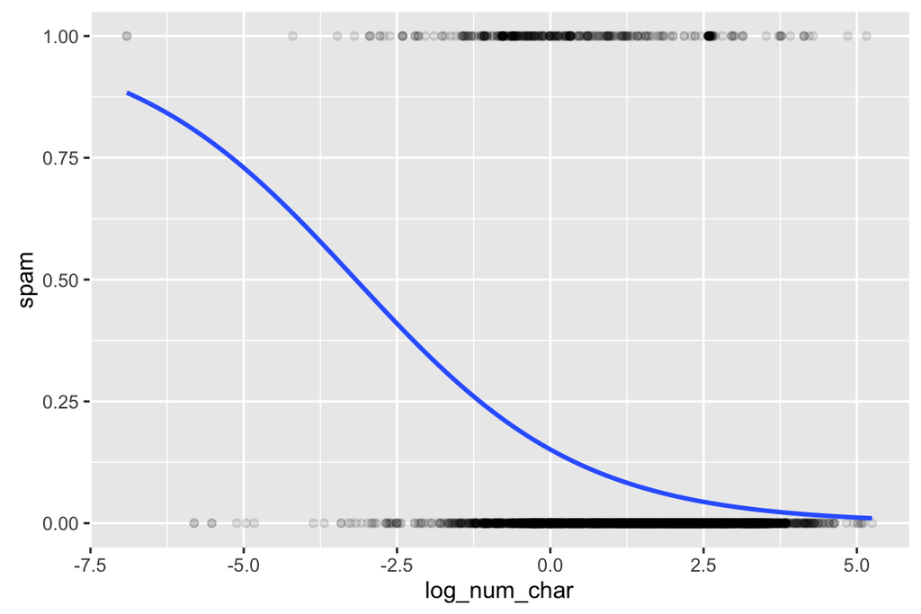

```r
m1 <- glm(spam ~ log(num_char), data = email, family = "binomial")
summary(m1)
```

```
##
## Call:
## glm(formula = spam ~ log(num_char), family = "binomial", data = email)
##
## Deviance Residuals:
##    Min      1Q  Median      3Q     Max
## -1.815  -0.467  -0.335  -0.255   3.013
##
## Coefficients:
##               Estimate Std. Error z value Pr(>|z|)
## (Intercept)    -1.7244     0.0606   -28.4   <2e-16 ***
## log(num_char)  -0.5435     0.0365   -14.9   <2e-16 ***
## ---
## Signif. codes:  0 '***' 0.001 '**' 0.01 '*' 0.05 '.' 0.1 ' ' 1
##
## (Dispersion parameter for binomial family taken to be 1)
##
##     Null deviance: 2437.2  on 3920  degrees of freedom
## Residual deviance: 2190.3  on 3919  degrees of freedom
## AIC: 2194
##
## Number of Fisher Scoring iterations: 5
```

## Interpreting Log. Reg.

1. Each row of the summary output is still a H-test on that parameter being 0.
2. A positive slope estimate indicates that there is a positive association.
3. Each estimate is still conditional on the other variables held constant.

## A more sophisticated model

```r
m2 <- glm(spam ~ log(num_char) + to_multiple + attach + dollar + inherit +
            viagra, data = email, family = "binomial")
summary(m2)
```

```
##
## Call:
## glm(formula = spam ~ log(num_char) + to_multiple + attach + dollar +
##     inherit + viagra, family = "binomial", data = email)
##
## Deviance Residuals:
##    Min      1Q  Median      3Q     Max
## -1.931  -0.455  -0.328  -0.236   3.034
##
## Coefficients:
##               Estimate Std. Error z value Pr(>|z|)
## (Intercept)   -1.59642    0.06443  -24.78  < 2e-16 ***
## log(num_char) -0.54869    0.03831  -14.32  < 2e-16 ***
## to_multiple   -1.92889    0.30493   -6.33  2.5e-10 ***
## attach         0.19970    0.06552    3.05   0.0023 **
## dollar        -0.00456    0.01898   -0.24   0.8102
## inherit        0.40003    0.15166    2.64   0.0083 **
## viagra         1.73607   40.59296    0.04   0.9659
## ---
## Signif. codes:  0 '***' 0.001 '**' 0.01 '*' 0.05 '.' 0.1 ' ' 1
##
## (Dispersion parameter for binomial family taken to be 1)
##
##     Null deviance: 2437.2  on 3920  degrees of freedom
## Residual deviance: 2106.3  on 3914  degrees of freedom
## AIC: 2120
##
## Number of Fisher Scoring iterations: 11
```

## Extending the model

A GLM consists of three things:

1. A linear predictor
2. A distribution of the response
3. A link function between the two

### MLR

Normal distribution, identity link function

### Logisitic Regression

Binomial distribution, logit link function

### Poisson Regression

Poisson distribution, logarithm